# Presenting the Problem

**Diabetes** is a disease that occurs either when the pancreas does not produce enough insulin or when the body can not effectively use the insulin it produces. **Insulin** is the hormone that reduces the glucose in the blood by acting on the entry of that glucose into the cell.

As people with diabetes can not produce sufficient insulin. they have to receive daily insulin injections to maintain normal blood glucose levels. However, this doses are not gradual and can cause many side effects.

Therefore, it is needed a more robust approach to this problem.

## Closed Loop Control

Recently, the availability of new products such as Continuous Glucose Monitors (CGM) and Insulin Pumps created the possibility of a Closed Loop System.

[figure not shown]

# Obtaining the Data

First, we need to collect the data used to solve our problem.

[figure not shown]

> Open Humans is a platform that allows you to upload, connect, and privately store your personal data – such as genetic, activity, or social media data. Once you've added data, you can choose to donate it: you might choose to share some publicly , and you can join and contribute to diverse research projects.

# Data Inspection

Now, let's take a look in the data.

```python
#data = pd.read_json('data2\\entries__to_2017-10-01.json')
entries = pd.read_csv('entries_combined.json', low_memory=False)
print(entries.shape)
entries.head()
```

```
(644258, 22)
```

|  | id | _id | date | dateString | delta | device | direction | display_time | filtered | glucose | ... | noise | rssi | scale | sgv | slope | sysTime | system_time | trend_arrow | type | unfiltered |
| --- | --- | --- | --- | --- | --- | --- | --- | --- | --- | --- | --- | --- | --- | --- | --- | --- | --- | --- | --- | --- | --- |
| 0 | 0 | 5a8a12774594dc43b99e99a7 | 2018-02-18 23:55:33.613 | 2018-02-18T18:55:33.613000-05:00 | NaN | xDrip-DexbridgeWixel | SingleUp | NaN | 218688.0 | 229.0 | ... | 1.0 | 100.0 | NaN | 229.0 | NaN | NaN | NaN | NaN | sgv | 234784.0 |
| 1 | 1 | 5a8a12774594dc43b99e99a7 | 2018-02-18 23:55:33.613 | 2018-02-18T18:55:33.613-0500 | NaN | xDrip-DexbridgeWixel | SingleUp | NaN | 218688.0 | NaN | ... | 1.0 | 100.0 | NaN | 229.0 | NaN | NaN | NaN | NaN | sgv | 234784.0 |
| 2 | 2 | 5a8a114b4594dc43b99e99a4 | 2018-02-18 23:50:33.880 | 2018-02-18T18:50:33.880-0500 | NaN | xDrip-DexbridgeWixel | Flat | NaN | 209568.0 | NaN | ... | 1.0 | 100.0 | NaN | 215.0 | NaN | NaN | NaN | NaN | sgv | 220736.0 |
| 3 | 3 | 5a8a101f4594dc43b99e99a1 | 2018-02-18 23:45:34.112 | 2018-02-18T18:45:34.112000-05:00 | NaN | xDrip-DexbridgeWixel | SingleUp | NaN | 200864.0 | 211.0 | ... | 1.0 | 100.0 | NaN | 211.0 | NaN | NaN | NaN | NaN | sgv | 216608.0 |
| 4 | 4 | 5a8a101f4594dc43b99e99a1 | 2018-02-18 23:45:34.112 | 2018-02-18T18:45:34.112-0500 | NaN | xDrip-DexbridgeWixel | SingleUp | NaN | 200864.0 | NaN | ... | 1.0 | 100.0 | NaN | 211.0 | NaN | NaN | NaN | NaN | sgv | 216608.0 |

5 rows × 22 columns

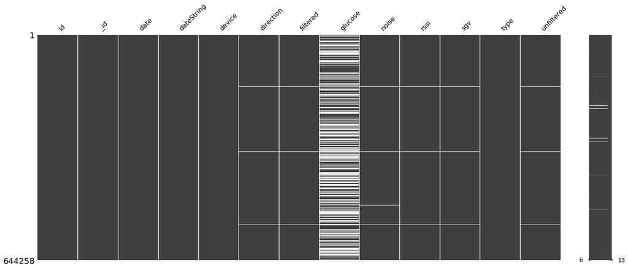

```python
# missing data
check = entries.dropna(how='any', axis=1, thresh=10000)
msno.matrix(check)
```

```python
entries.isnull().sum()
```

```
id                   0
_id                  0
date                 0
dateString           0
delta           643834
device               0
direction         4264
display_time    643058
filtered          4304
glucose         303058
intercept       642128
mbg             642124
noise             5464
rssi              4304
scale           642128
sgv               4264
slope           642128
sysTime         643834
system_time     643058
trend_arrow     643058
type                 0
unfiltered        4304
dtype: int64
```

```python
# Data of interest
bg_data = entries[['date', 'glucose', 'filtered', 'unfiltered']]
print(bg_data.shape)
bg_data.head()
```

```
(644258, 4)
```

|  | date | glucose | filtered | unfiltered |
| --- | --- | --- | --- | --- |
| 0 | 2018-02-18 23:55:33.613 | 229.0 | 218688.0 | 234784.0 |
| 1 | 2018-02-18 23:55:33.613 | NaN | 218688.0 | 234784.0 |
| 2 | 2018-02-18 23:50:33.880 | NaN | 209568.0 | 220736.0 |
| 3 | 2018-02-18 23:45:34.112 | 211.0 | 200864.0 | 216608.0 |
| 4 | 2018-02-18 23:45:34.112 | NaN | 200864.0 | 216608.0 |

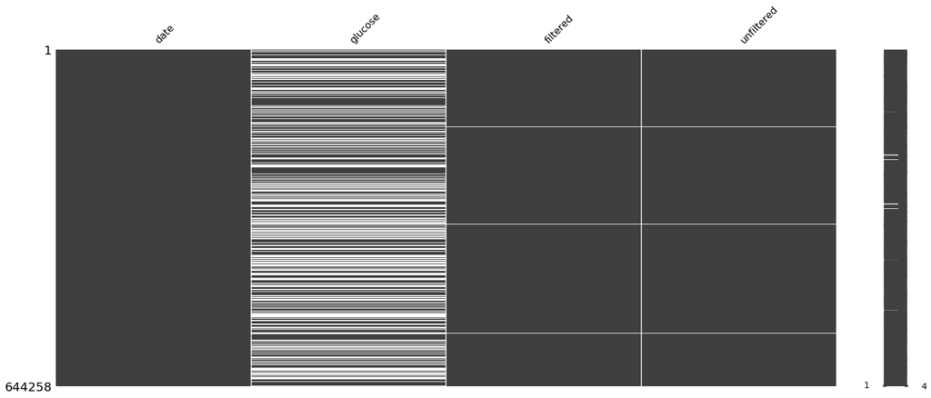

```python
# missing data
msno.matrix(bg_data)
```

```python
# Remove Duplicates
bg_data = bg_data.drop_duplicates()
print(bg_data.shape)
bg_data.head()
```

```
(215444, 4)
```

|  | date | glucose | filtered | unfiltered |
| --- | --- | --- | --- | --- |
| 0 | 2018-02-18 23:55:33.613 | 229.0 | 218688.0 | 234784.0 |
| 1 | 2018-02-18 23:55:33.613 | NaN | 218688.0 | 234784.0 |
| 2 | 2018-02-18 23:50:33.880 | NaN | 209568.0 | 220736.0 |
| 3 | 2018-02-18 23:45:34.112 | 211.0 | 200864.0 | 216608.0 |
| 4 | 2018-02-18 23:45:34.112 | NaN | 200864.0 | 216608.0 |

```python
# Drop NaN
bg_data = bg_data.dropna()
print(bg_data.shape)
bg_data.head()
```

```
(99881, 3)
```

| date | glucose | filtered | unfiltered |
| --- | --- | --- | --- |
| 2017-04-27 02:35:42.344 | 127.0 | 46784.0 | 51648.0 |
| 2017-04-27 02:40:42.329 | 126.0 | 48312.0 | 50472.0 |
| 2017-04-27 02:45:42.335 | 138.0 | 51704.0 | 59616.0 |
| 2017-04-27 03:10:41.556 | 133.0 | 53296.0 | 55960.0 |
| 2017-04-27 03:20:41.339 | 116.0 | 53512.0 | 43168.0 |

# EDA

Now, let explore the data with visualizations.

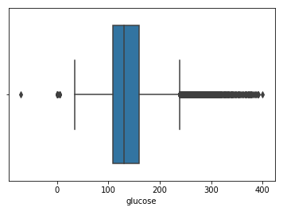

```python
sns.boxplot(bg_data.glucose)
```

```python
bg_data.describe()
```

|  | glucose | filtered | unfiltered |
| --- | --- | --- | --- |
| count | 99881.000000 | 9.988100e+04 | 9.988100e+04 |
| mean | 137.733603 | 1.511858e+05 | 1.507464e+05 |
| std | 41.125953 | 6.125313e+04 | 4.930576e+04 |
| min | -71.000000 | 1.260000e+02 | 0.000000e+00 |
| 25% | 108.000000 | 1.196160e+05 | 1.196406e+05 |
| 50% | 130.000000 | 1.452800e+05 | 1.453440e+05 |
| 75% | 160.000000 | 1.769600e+05 | 1.772800e+05 |
| max | 400.000000 | 2.096896e+06 | 1.048448e+06 |

```python
bg_data.glucose.sort_values().head(15)
```

```
date
2017-08-07 21:45:21.830   -71.0
2017-06-21 11:59:53.377     0.0
2018-06-21 10:35:43.197     0.0
2017-06-05 23:00:28.422     0.0
2017-11-20 12:09:12.658     0.0
2018-01-07 22:27:39.265     0.0
2017-07-05 14:54:21.020     0.0
2017-05-04 14:00:17.375     0.0
2017-08-26 20:37:24.663     0.0
2017-12-16 16:19:21.000     5.0
2017-12-16 16:29:20.000     5.0
2017-12-16 16:34:20.000     5.0
2017-12-16 16:24:20.000     5.0
2018-05-19 21:22:03.017    35.0
2017-05-31 07:33:17.406    38.0
Name: glucose, dtype: float64
```

```python
bg_data.glucose.sort_values(ascending=False).head(15)
```

```
date
2017-12-16 01:48:55.545    400.0
2018-03-09 03:39:51.161    392.0
2018-03-09 03:29:51.290    391.0
2018-03-09 03:24:51.286    390.0
2018-03-09 03:44:51.279    387.0
2018-03-09 03:19:51.271    385.0
2018-06-30 20:05:21.965    383.0
2018-03-09 03:49:51.282    382.0
2018-06-30 20:10:21.977    379.0
2018-06-30 19:55:21.969    378.0
2018-03-09 03:54:51.278    378.0
2018-03-09 03:14:51.281    378.0
2018-03-09 03:09:50.451    377.0
2018-03-09 03:59:51.293    375.0
2017-10-21 03:35:20.601    375.0
Name: glucose, dtype: float64
```

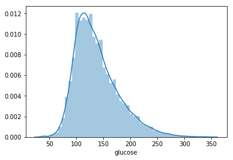

```python
# Remove Outliers
bg_data = bg_data[(bg_data.glucose > 20) & (bg_data.glucose < 350)]
sns.distplot(bg_data.glucose)
```

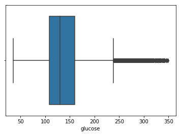

```python
sns.boxplot(bg_data.glucose)
```

```python
bg_data.shape
```

[output not shown]

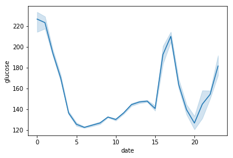

```python
# Example
day = bg_data['2017-06-30']
sns.lineplot(day.index.hour, day.glucose)
```

# Sequential Models

Sequence models can make use of sequential information, which is a perfect case for our problem.

> Another way to think about this type of model is that they have a “memory” which captures information about what has been calculated so far.In theory, sequence models can make use of information in arbitrarily long sequences.

There are 3 principal models:

- RNN
- LSTM
- GRU

## Prepare the Data

Before, apply the sequential data to the RNN, two conditions should be fulfilled:

1. Time data should be equally spaced and without missing values.
2. The target values should be created by shifting the time series.

```python
# Prepare the data as equaly spaced data
data = bg_data[['glucose']].resample('5Min').mean()
data = data.interpolate('linear')
print(data.isnull().sum())
print(data.shape)

data.head()
```

```
glucose    0
dtype: int64
(127524, 1)
```

| date | glucose |
| --- | --- |
| 2017-04-27 02:35:00 | 127.0 |
| 2017-04-27 02:40:00 | 126.0 |
| 2017-04-27 02:45:00 | 138.0 |
| 2017-04-27 02:50:00 | 137.0 |
| 2017-04-27 02:55:00 | 136.0 |

```python
# Create target for each value
data['target'] = data.glucose.shift(1)
print(data.shape)

data.head()
```

```
(127524, 2)
```

| date | glucose | target |
| --- | --- | --- |
| 2017-04-27 02:35:00 | 127.0 | NaN |
| 2017-04-27 02:40:00 | 126.0 | 127.0 |
| 2017-04-27 02:45:00 | 138.0 | 126.0 |
| 2017-04-27 02:50:00 | 137.0 | 138.0 |
| 2017-04-27 02:55:00 | 136.0 | 137.0 |

# RNN

[figure not shown]

```python
# Model
class RNN(nn.Module):
    def __init__(self, input_size, output_size, n_hidden, n_layers, drop_prob=0.5):
        super(RNN, self).__init__()
        self.n_hidden = n_hidden
        self.n_layers = n_layers
        self.n_input = input_size
        self.output_size = output_size
        self.drop_prob = drop_prob
        self.name = 'RNN'

        # define an RNN with specified parameters
        # batch_first means that the first dim of the input and output will be the batch_size
        self.rnn = nn.RNN(input_size, n_hidden, n_layers, batch_first=True, dropout=drop_prob)

        # last, fully-connected layer
        self.fc = nn.Linear(n_hidden, output_size)

    def forward(self, x, hidden):
        # x (batch_size, seq_length, input_size)
        # hidden (n_layers, batch_size, hidden_dim)
        # r_out (batch_size, time_step, hidden_size)
        batch_size = x.size(0)

        # get RNN outputs
        r_out, hidden = self.rnn(x, hidden)
        # shape output to be (batch_size*seq_length, hidden_dim)
        r_out = r_out.contiguous().view(-1, self.n_hidden)

        # get final output
        output = self.fc(r_out)
        #output.view(batch_size, -1, self.output_size)

        return output, hidden
```

```python
# check if GPU is available
train_on_gpu = torch.cuda.is_available()
if(train_on_gpu):
    print('Training on GPU!')
else:
    print('No GPU available, training on CPU; consider making n_epochs very small.')
```

```
Training on GPU!
```

```python
def train(net, data, epochs=10, batch_size=10, seq_length=50, lr=0.001, clip=5, val_frac=0.1, print_every=10):
    ''' Training a network

        Arguments
        ---------

        net: RNN network
        data: data to train the network
        epochs: Number of epochs to train
        batch_size: Number of mini-sequences per mini-batch, aka batch size
        seq_length: Sequence length
        lr: learning rate
        clip: gradient clipping
        val_frac: Fraction of data to hold out for validation
        print_every: Number of steps for printing training and validation loss

    '''
    net.train()

    opt = torch.optim.Adam(net.parameters(), lr=lr)
    criterion = nn.MSELoss()

    # create training and validation data
    val_idx = int(len(data) * (1 - val_frac))
    data, val_data = data[:val_idx], data[val_idx:]

    if(train_on_gpu):
        net.cuda()

    # Best Loss
    best_avg_loss = np.infty
    counter = 0
    for e in range(epochs):
        # initialize hidden state
        h = None#net.init_hidden(batch_size)

        for x, y in get_batches(data, batch_size, seq_length):
            counter += 1

            # Reshape inputs and targets
            x = x[:, :, np.newaxis]
            y = y[:, :, np.newaxis]
            inputs, targets = torch.from_numpy(x), torch.from_numpy(y)

            if(train_on_gpu):
                inputs, targets = inputs.cuda(), targets.cuda()

            # zero accumulated gradients
            net.zero_grad()

            # get the output from the model
            output, h = net(inputs.float(), h)

            # Creating new variables for the hidden state, otherwise
            # we'd backprop through the entire training history
            if isinstance(h, tuple):
                h = tuple([each.data for each in h])
            else:
                h = h.data

            # calculate the loss and perform backprop
            loss = criterion(output.squeeze(), targets.view(batch_size * seq_length).float())

            loss.backward()

            # `clip_grad_norm` helps prevent the exploding gradient problem in RNNs / LSTMs.
            nn.utils.clip_grad_norm_(net.parameters(), clip)
            opt.step()

            # loss stats
            if counter % print_every == 0:
                # Get validation loss
                val_h = None#net.init_hidden(batch_size)
                val_losses = []

                net.eval()

                for x_val, y_val in get_batches(val_data, batch_size, seq_length):
                    # One-hot encode our data and make them Torch tensors
                    x_val = x_val[:, :, np.newaxis]
                    y_val = y_val[:, :, np.newaxis]
                    x_val, y_val = torch.from_numpy(x), torch.from_numpy(y)

                    inputs, targets = x_val, y_val
                    if(train_on_gpu):
                        inputs, targets = inputs.cuda(), targets.cuda()

                    output, val_h = net(inputs.float(), val_h)

                    val_loss = criterion(output.squeeze(), targets.view(batch_size * seq_length).float())

                    val_losses.append(val_loss.item())

                net.train() # reset to train mode after iterationg through validation data
                # Saves if val loss reduced
                new_val_loss = np.mean(val_losses)
                save_model = new_val_loss <= best_avg_loss

                if save_model:
                    # change the name, for saving multiple files
                    model_name = str(net.name) + 'rnn_epoch_' + str(e) + '.net'

                    checkpoint = {'n_hidden': net.n_hidden,
                                  'n_layers': net.n_layers,
                                  'state_dict': net.state_dict(),
                                  'n_input':net.n_input
                                  }

                    with open(model_name, 'wb') as f:
                        torch.save(checkpoint, f)
                    # updated best loss
                    best_avg_loss = new_val_loss

                print("Epoch: {}/{}...".format(e + 1, epochs),
                      "Step: {}...".format(counter),
                      "Loss: {:.4f}...".format(loss.item()),
                      "Val Loss: {:.4f}".format(new_val_loss),
                      "Model Saved: {}".format(save_model))
```

```python
# define and print the net
input_size = 1
output_size = 1
n_hidden = 512
n_layers = 2

net = RNN(input_size, output_size, n_hidden, n_layers)
print(net)
```

```
RNN(
  (rnn): RNN(1, 512, num_layers=2, batch_first=True, dropout=0.5)
  (fc): Linear(in_features=512, out_features=1, bias=True)
)
```

```python
batch_size = 16
seq_length = 288
n_epochs = 150

# train the model
train(net, data.values, epochs=n_epochs, batch_size=batch_size, seq_length=seq_length, val_frac=.15,lr=0.001, print_every=100)
```

```
Epoch: 5/150... Step: 100... Loss: 28.0725... Val Loss: 29.1613 Model Saved: True
Epoch: 9/150... Step: 200... Loss: 33.9772... Val Loss: 36.0495 Model Saved: False
Epoch: 14/150... Step: 300... Loss: 79.1104... Val Loss: 75.1161 Model Saved: False
Epoch: 18/150... Step: 400... Loss: 28.5554... Val Loss: 38.1136 Model Saved: False
Epoch: 22/150... Step: 500... Loss: 46.8695... Val Loss: 48.1249 Model Saved: False
Epoch: 27/150... Step: 600... Loss: 47.9301... Val Loss: 49.0420 Model Saved: False
Epoch: 31/150... Step: 700... Loss: 42.1913... Val Loss: 41.8323 Model Saved: False
Epoch: 35/150... Step: 800... Loss: 48.4234... Val Loss: 50.9759 Model Saved: False
Epoch: 40/150... Step: 900... Loss: 52.7956... Val Loss: 54.3055 Model Saved: False
Epoch: 44/150... Step: 1000... Loss: 23.3191... Val Loss: 23.8351 Model Saved: True
Epoch: 48/150... Step: 1100... Loss: 43.8034... Val Loss: 44.2792 Model Saved: False
Epoch: 53/150... Step: 1200... Loss: 51.5493... Val Loss: 53.0009 Model Saved: False
Epoch: 57/150... Step: 1300... Loss: 32.0287... Val Loss: 31.6268 Model Saved: False
Epoch: 61/150... Step: 1400... Loss: 49.7900... Val Loss: 51.5305 Model Saved: False
Epoch: 66/150... Step: 1500... Loss: 38.0424... Val Loss: 38.3782 Model Saved: False
Epoch: 70/150... Step: 1600... Loss: 16.8365... Val Loss: 15.4594 Model Saved: True
Epoch: 74/150... Step: 1700... Loss: 52.3936... Val Loss: 50.3042 Model Saved: False
Epoch: 79/150... Step: 1800... Loss: 29.1623... Val Loss: 31.6438 Model Saved: False
Epoch: 83/150... Step: 1900... Loss: 27.3460... Val Loss: 27.0517 Model Saved: False
Epoch: 87/150... Step: 2000... Loss: 52.0390... Val Loss: 53.3605 Model Saved: False
Epoch: 92/150... Step: 2100... Loss: 33.4524... Val Loss: 39.3213 Model Saved: False
Epoch: 96/150... Step: 2200... Loss: 30.4608... Val Loss: 30.6743 Model Saved: False
Epoch: 100/150... Step: 2300... Loss: 79.8576... Val Loss: 80.1965 Model Saved: False
Epoch: 105/150... Step: 2400... Loss: 28.8001... Val Loss: 29.8163 Model Saved: False
Epoch: 109/150... Step: 2500... Loss: 30.5691... Val Loss: 31.9208 Model Saved: False
Epoch: 114/150... Step: 2600... Loss: 77.7854... Val Loss: 73.4431 Model Saved: False
Epoch: 118/150... Step: 2700... Loss: 28.2672... Val Loss: 30.2800 Model Saved: False
Epoch: 122/150... Step: 2800... Loss: 45.3103... Val Loss: 47.5213 Model Saved: False
Epoch: 127/150... Step: 2900... Loss: 45.4739... Val Loss: 46.6361 Model Saved: False
Epoch: 131/150... Step: 3000... Loss: 37.4102... Val Loss: 36.9696 Model Saved: False
Epoch: 135/150... Step: 3100... Loss: 44.8423... Val Loss: 51.5450 Model Saved: False
Epoch: 140/150... Step: 3200... Loss: 50.6308... Val Loss: 54.0221 Model Saved: False
Epoch: 144/150... Step: 3300... Loss: 22.3239... Val Loss: 23.3748 Model Saved: False
Epoch: 148/150... Step: 3400... Loss: 42.7727... Val Loss: 41.9872 Model Saved: False
```

```python
def predict(net, inp, time_steps=5, h=None):
        ''' Given an input, predict the output for n_predicted timesteps.
            Returns the predicted output and the hidden state.
        '''
        net.eval()

        # Outputs
        outputs = []

        # Tensor inputs - all values as sequence
        inputs = torch.from_numpy(inp)
        inputs = inputs.view(1, -1, 1)

        if(train_on_gpu):
            inputs = inputs.cuda().float()

        for ii in range(time_steps):
            # get the output of the model
            out, h = net(inputs, h)
            value_out = out[-1].detach().cpu().numpy().squeeze()
            outputs.append(value_out)
            #print(out.size())
            # updates input
            inputs = out.view(1, -1, 1)

        # return the encoded value of the predicted char and the hidden state
        return outputs
```

```python
start_date = '2018-06-20 00:00:00'
end_date = '2018-06-20 10:00:00'
initial_values = day[start_date:end_date]
time_steps = 60
```

```python
# Predictions
predicted_values = predict(net, initial_values.values, time_steps, h=None)
# DateTime index of predictions
pred_index = pd.date_range(start=end_date, periods=time_steps, freq='5Min')

# Predictions as Series
predictions_series = pd.Series(predicted_values, index=pred_index).astype('int')
```

```python
# Plots
real_values = day[day.index.isin(pred_index)]
plot_df = pd.concat([initial_values, real_values, predictions_series], axis=1)
plot_df.columns = ['Initial Values', 'Real Values', 'RNN']
#plot_df = day.merge(initial_values)
#plot_df = plotdf.merge()
#plot_df.loc[end_date, 'Predictions'] = real_values[end_date]
plot_df.head()
```

| date | Initial Values | Real Values | RNN |
| --- | --- | --- | --- |
| 2018-06-20 00:00:00 | 71.0 | NaN | NaN |
| 2018-06-20 00:05:00 | 73.0 | NaN | NaN |
| 2018-06-20 00:10:00 | 79.5 | NaN | NaN |
| 2018-06-20 00:15:00 | 86.0 | NaN | NaN |
| 2018-06-20 00:20:00 | 92.0 | NaN | NaN |

```python
plot_df.isnull().sum()
```

```
Initital Values     59
Real Values        120
RNN                120
dtype: int64
```

```python
plot_df.dtypes
```

```
Initital Values    float64
Real Values        float64
RNN                float64
dtype: object
```

# LSTM

[figure not shown]

```python
class LSTM(nn.Module):

    def __init__(self, input_size, output_size, n_hidden=256, n_layers=2,
                               drop_prob=0.5):
        super().__init__()
        self.n_input = input_size
        self.n_output = output_size
        self.drop_prob = drop_prob
        self.n_layers = n_layers
        self.n_hidden = n_hidden
        self.name = 'LSTM'

        ## TODO: define the LSTM
        self.lstm = nn.LSTM(input_size, n_hidden, n_layers,
                            dropout=drop_prob, batch_first=True)

        ## TODO: define a dropout layer
        self.dropout = nn.Dropout(drop_prob)

        ## TODO: define the final, fully-connected output layer
        self.fc = nn.Linear(n_hidden, output_size)


    def forward(self, x, hidden):
        ''' Forward pass through the network.
            These inputs are x, and the hidden/cell state `hidden`. '''

        ## TODO: Get the outputs and the new hidden state from the lstm
        r_output, hidden = self.lstm(x, hidden)

        ## TODO: pass through a dropout layer
        out = self.dropout(r_output)

        # Stack up LSTM outputs using view
        # you may need to use contiguous to reshape the output
        out = out.contiguous().view(-1, self.n_hidden)

        ## TODO: put x through the fully-connected layer
        out = self.fc(out)

        # return the final output and the hidden state
        return out, hidden
```

```python
# define and print the net
input_size = 1
output_size = 1
n_hidden = 256
n_layers = 2

lstm = LSTM(input_size, output_size, n_hidden, n_layers, drop_prob=.5)
print(lstm)
```

```
LSTM(
  (lstm): LSTM(1, 256, num_layers=2, batch_first=True, dropout=0.5)
  (dropout): Dropout(p=0.5)
  (fc): Linear(in_features=256, out_features=1, bias=True)
)
```

```python
batch_size = 16
seq_length = 288
n_epochs = 250 # start smaller if you are just testing initial behavior

# train the model
train(lstm, data.values, epochs=n_epochs, batch_size=batch_size, seq_length=seq_length, val_frac=.15,lr=0.001, print_every=100)
```

```
Epoch: 5/250... Step: 100... Loss: 937.3339... Val Loss: 852.8977 Model Saved: True
Epoch: 9/250... Step: 200... Loss: 734.9344... Val Loss: 659.4532 Model Saved: True
Epoch: 14/250... Step: 300... Loss: 457.6614... Val Loss: 367.7971 Model Saved: True
Epoch: 18/250... Step: 400... Loss: 436.3925... Val Loss: 360.4458 Model Saved: True
Epoch: 22/250... Step: 500... Loss: 432.7799... Val Loss: 354.1247 Model Saved: True
Epoch: 27/250... Step: 600... Loss: 355.4623... Val Loss: 271.2172 Model Saved: True
Epoch: 31/250... Step: 700... Loss: 341.7371... Val Loss: 297.5770 Model Saved: False
Epoch: 35/250... Step: 800... Loss: 421.5574... Val Loss: 334.2065 Model Saved: False
Epoch: 40/250... Step: 900... Loss: 354.8755... Val Loss: 268.3491 Model Saved: True
Epoch: 44/250... Step: 1000... Loss: 186.6897... Val Loss: 78.1186 Model Saved: True
Epoch: 48/250... Step: 1100... Loss: 253.6881... Val Loss: 160.9742 Model Saved: False
Epoch: 53/250... Step: 1200... Loss: 323.4603... Val Loss: 231.3957 Model Saved: False
Epoch: 57/250... Step: 1300... Loss: 153.3360... Val Loss: 61.7602 Model Saved: True
Epoch: 61/250... Step: 1400... Loss: 269.8390... Val Loss: 189.4107 Model Saved: False
Epoch: 66/250... Step: 1500... Loss: 146.2706... Val Loss: 58.1295 Model Saved: True
Epoch: 70/250... Step: 1600... Loss: 131.1358... Val Loss: 43.1234 Model Saved: True
Epoch: 74/250... Step: 1700... Loss: 138.9632... Val Loss: 75.7323 Model Saved: False
Epoch: 79/250... Step: 1800... Loss: 141.0639... Val Loss: 67.3065 Model Saved: False
Epoch: 83/250... Step: 1900... Loss: 155.4636... Val Loss: 70.1897 Model Saved: False
Epoch: 87/250... Step: 2000... Loss: 171.0567... Val Loss: 86.4569 Model Saved: False
Epoch: 92/250... Step: 2100... Loss: 155.7017... Val Loss: 57.9096 Model Saved: False
Epoch: 96/250... Step: 2200... Loss: 248.8374... Val Loss: 163.2677 Model Saved: False
Epoch: 100/250... Step: 2300... Loss: 168.0339... Val Loss: 111.0910 Model Saved: False
Epoch: 105/250... Step: 2400... Loss: 131.9188... Val Loss: 42.2996 Model Saved: True
Epoch: 109/250... Step: 2500... Loss: 158.1633... Val Loss: 84.9726 Model Saved: False
Epoch: 114/250... Step: 2600... Loss: 191.7603... Val Loss: 103.0513 Model Saved: False
Epoch: 118/250... Step: 2700... Loss: 133.0835... Val Loss: 42.0580 Model Saved: True
Epoch: 122/250... Step: 2800... Loss: 251.3745... Val Loss: 141.2293 Model Saved: False
Epoch: 127/250... Step: 2900... Loss: 168.7578... Val Loss: 83.6998 Model Saved: False
Epoch: 131/250... Step: 3000... Loss: 150.7448... Val Loss: 99.9877 Model Saved: False
Epoch: 135/250... Step: 3100... Loss: 204.2003... Val Loss: 114.3656 Model Saved: False
Epoch: 140/250... Step: 3200... Loss: 179.8197... Val Loss: 90.4573 Model Saved: False
Epoch: 144/250... Step: 3300... Loss: 115.0460... Val Loss: 26.9487 Model Saved: True
Epoch: 148/250... Step: 3400... Loss: 168.3080... Val Loss: 64.4026 Model Saved: False
Epoch: 153/250... Step: 3500... Loss: 169.5547... Val Loss: 85.0395 Model Saved: False
Epoch: 157/250... Step: 3600... Loss: 122.7353... Val Loss: 39.0657 Model Saved: False
Epoch: 161/250... Step: 3700... Loss: 151.2417... Val Loss: 70.7843 Model Saved: False
Epoch: 166/250... Step: 3800... Loss: 139.1048... Val Loss: 54.8966 Model Saved: False
Epoch: 170/250... Step: 3900... Loss: 98.6707... Val Loss: 16.4764 Model Saved: True
Epoch: 174/250... Step: 4000... Loss: 148.6935... Val Loss: 71.7521 Model Saved: False
Epoch: 179/250... Step: 4100... Loss: 129.2989... Val Loss: 38.4232 Model Saved: False
Epoch: 183/250... Step: 4200... Loss: 122.3712... Val Loss: 36.5874 Model Saved: False
Epoch: 187/250... Step: 4300... Loss: 153.0736... Val Loss: 77.7184 Model Saved: False
Epoch: 192/250... Step: 4400... Loss: 134.7296... Val Loss: 41.7821 Model Saved: False
Epoch: 196/250... Step: 4500... Loss: 142.0820... Val Loss: 48.5031 Model Saved: False
Epoch: 200/250... Step: 4600... Loss: 165.8011... Val Loss: 102.6623 Model Saved: False
Epoch: 205/250... Step: 4700... Loss: 123.7641... Val Loss: 34.0333 Model Saved: False
Epoch: 209/250... Step: 4800... Loss: 129.1669... Val Loss: 37.4819 Model Saved: False
Epoch: 214/250... Step: 4900... Loss: 168.2808... Val Loss: 80.0386 Model Saved: False
Epoch: 218/250... Step: 5000... Loss: 143.7420... Val Loss: 46.6670 Model Saved: False
Epoch: 222/250... Step: 5100... Loss: 153.2391... Val Loss: 67.4628 Model Saved: False
Epoch: 227/250... Step: 5200... Loss: 144.7033... Val Loss: 84.8207 Model Saved: False
Epoch: 231/250... Step: 5300... Loss: 139.2188... Val Loss: 54.3459 Model Saved: False
Epoch: 235/250... Step: 5400... Loss: 170.4743... Val Loss: 79.9952 Model Saved: False
Epoch: 240/250... Step: 5500... Loss: 141.5154... Val Loss: 65.3846 Model Saved: False
Epoch: 244/250... Step: 5600... Loss: 104.4789... Val Loss: 23.6119 Model Saved: False
Epoch: 248/250... Step: 5700... Loss: 141.2127... Val Loss: 48.8764 Model Saved: False
```

```python
# Predictions
lstm_predicted_values = predict(lstm, initial_values.values, time_steps, h=None)

# Predictions as Series
lstm_predictions_series = pd.Series(lstm_predicted_values, index=pred_index).astype('int')
```

```python
# Plots

plot_df['LSTM'] = lstm_predictions_series
#plot_df = day.merge(initial_values)
#plot_df = plotdf.merge()
#plot_df.loc[end_date, 'Predictions'] = real_values[end_date]
plot_df.head()
```

| date | Initial Values | Real Values | RNN | LSTM |
| --- | --- | --- | --- | --- |
| 2018-06-20 00:00:00 | 71.0 | NaN | NaN | NaN |
| 2018-06-20 00:05:00 | 73.0 | NaN | NaN | NaN |
| 2018-06-20 00:10:00 | 79.5 | NaN | NaN | NaN |
| 2018-06-20 00:15:00 | 86.0 | NaN | NaN | NaN |
| 2018-06-20 00:20:00 | 92.0 | NaN | NaN | NaN |

# GRU

[figure not shown]

```python
class GRU(nn.Module):

    def __init__(self, input_size, output_size, n_hidden=256, n_layers=2,
                               drop_prob=0.5):
        super().__init__()
        self.n_input = input_size
        self.n_output = output_size
        self.drop_prob = drop_prob
        self.n_layers = n_layers
        self.n_hidden = n_hidden
        self.name = 'GRU'

        ## TODO: define the LSTM
        self.gru = nn.GRU(input_size, n_hidden, n_layers,
                            dropout=drop_prob, batch_first=True)

        ## TODO: define a dropout layer
        self.dropout = nn.Dropout(drop_prob)

        ## TODO: define the final, fully-connected output layer
        self.fc = nn.Linear(n_hidden, output_size)


    def forward(self, x, hidden):
        ''' Forward pass through the network.
            These inputs are x, and the hidden/cell state `hidden`. '''

        ## TODO: Get the outputs and the new hidden state from the lstm
        r_output, hidden = self.gru(x, hidden)

        ## TODO: pass through a dropout layer
        out = self.dropout(r_output)

        # Stack up LSTM outputs using view
        # you may need to use contiguous to reshape the output
        out = out.contiguous().view(-1, self.n_hidden)

        ## TODO: put x through the fully-connected layer
        out = self.fc(out)

        # return the final output and the hidden state
        return out, hidden
```

```python
# define and print the net
input_size = 1
output_size = 1
n_hidden = 256
n_layers = 2

gru = GRU(input_size, output_size, n_hidden, n_layers, drop_prob=.5)
print(gru)
```

```
GRU(
  (gru): GRU(1, 256, num_layers=2, batch_first=True, dropout=0.5)
  (dropout): Dropout(p=0.5)
  (fc): Linear(in_features=256, out_features=1, bias=True)
)
```

```python
batch_size = 8
seq_length = 288
n_epochs = 250 # start smaller if you are just testing initial behavior

# train the model
train(gru, data.values, epochs=n_epochs, batch_size=batch_size, seq_length=seq_length, val_frac=.15,lr=0.001, print_every=100)
```

```
Epoch: 3/250... Step: 100... Loss: 115.2587... Val Loss: 22.3271 Model Saved: True
Epoch: 5/250... Step: 200... Loss: 125.6841... Val Loss: 16.1986 Model Saved: True
Epoch: 7/250... Step: 300... Loss: 128.4845... Val Loss: 56.3936 Model Saved: False
Epoch: 9/250... Step: 400... Loss: 132.4942... Val Loss: 51.2306 Model Saved: False
Epoch: 11/250... Step: 500... Loss: 121.6540... Val Loss: 35.1857 Model Saved: False
Epoch: 13/250... Step: 600... Loss: 137.0219... Val Loss: 41.8895 Model Saved: False
Epoch: 15/250... Step: 700... Loss: 123.5374... Val Loss: 63.5951 Model Saved: False
Epoch: 18/250... Step: 800... Loss: 163.6803... Val Loss: 63.7569 Model Saved: False
Epoch: 20/250... Step: 900... Loss: 119.6910... Val Loss: 34.6056 Model Saved: False
Epoch: 22/250... Step: 1000... Loss: 112.4411... Val Loss: 18.9822 Model Saved: False
Epoch: 24/250... Step: 1100... Loss: 141.1550... Val Loss: 69.7099 Model Saved: False
Epoch: 26/250... Step: 1200... Loss: 124.0991... Val Loss: 39.8115 Model Saved: False
Epoch: 28/250... Step: 1300... Loss: 117.1618... Val Loss: 27.3648 Model Saved: False
Epoch: 30/250... Step: 1400... Loss: 165.9483... Val Loss: 93.0823 Model Saved: False
Epoch: 32/250... Step: 1500... Loss: 132.3519... Val Loss: 64.9205 Model Saved: False
Epoch: 35/250... Step: 1600... Loss: 121.6207... Val Loss: 37.6030 Model Saved: False
Epoch: 37/250... Step: 1700... Loss: 103.5330... Val Loss: 32.1359 Model Saved: False
Epoch: 39/250... Step: 1800... Loss: 134.0977... Val Loss: 25.6219 Model Saved: False
Epoch: 41/250... Step: 1900... Loss: 145.1346... Val Loss: 71.1457 Model Saved: False
Epoch: 43/250... Step: 2000... Loss: 130.6778... Val Loss: 50.1885 Model Saved: False
Epoch: 45/250... Step: 2100... Loss: 105.5288... Val Loss: 29.4150 Model Saved: False
Epoch: 47/250... Step: 2200... Loss: 149.2100... Val Loss: 57.6898 Model Saved: False
Epoch: 49/250... Step: 2300... Loss: 137.0380... Val Loss: 57.7700 Model Saved: False
Epoch: 52/250... Step: 2400... Loss: 143.1329... Val Loss: 57.6188 Model Saved: False
Epoch: 54/250... Step: 2500... Loss: 117.3381... Val Loss: 34.4612 Model Saved: False
Epoch: 56/250... Step: 2600... Loss: 142.4696... Val Loss: 56.3177 Model Saved: False
Epoch: 58/250... Step: 2700... Loss: 141.7509... Val Loss: 63.3591 Model Saved: False
Epoch: 60/250... Step: 2800... Loss: 101.1703... Val Loss: 45.2791 Model Saved: False
Epoch: 62/250... Step: 2900... Loss: 102.5880... Val Loss: 20.1015 Model Saved: False
Epoch: 64/250... Step: 3000... Loss: 150.4232... Val Loss: 61.6220 Model Saved: False
Epoch: 66/250... Step: 3100... Loss: 167.4897... Val Loss: 84.9181 Model Saved: False
Epoch: 69/250... Step: 3200... Loss: 107.7272... Val Loss: 29.0068 Model Saved: False
Epoch: 71/250... Step: 3300... Loss: 117.3257... Val Loss: 39.0161 Model Saved: False
Epoch: 73/250... Step: 3400... Loss: 122.2483... Val Loss: 50.4908 Model Saved: False
Epoch: 75/250... Step: 3500... Loss: 152.0574... Val Loss: 84.1227 Model Saved: False
Epoch: 77/250... Step: 3600... Loss: 121.0025... Val Loss: 33.7798 Model Saved: False
Epoch: 79/250... Step: 3700... Loss: 111.6979... Val Loss: 38.3508 Model Saved: False
Epoch: 81/250... Step: 3800... Loss: 130.9463... Val Loss: 61.8630 Model Saved: False
Epoch: 83/250... Step: 3900... Loss: 156.7149... Val Loss: 66.9621 Model Saved: False
Epoch: 86/250... Step: 4000... Loss: 110.9881... Val Loss: 25.6851 Model Saved: False
```

[output cut: 62 more lines]

```
Epoch: 220/250... Step: 10300... Loss: 100.1830... Val Loss: 23.5043 Model Saved: False
Epoch: 222/250... Step: 10400... Loss: 101.9249... Val Loss: 21.2171 Model Saved: False
Epoch: 224/250... Step: 10500... Loss: 125.5039... Val Loss: 68.0517 Model Saved: False
Epoch: 226/250... Step: 10600... Loss: 111.5931... Val Loss: 49.1953 Model Saved: False
Epoch: 228/250... Step: 10700... Loss: 97.0923... Val Loss: 21.0858 Model Saved: False
Epoch: 230/250... Step: 10800... Loss: 146.7057... Val Loss: 72.9919 Model Saved: False
Epoch: 232/250... Step: 10900... Loss: 126.2483... Val Loss: 68.2262 Model Saved: False
Epoch: 235/250... Step: 11000... Loss: 116.0860... Val Loss: 32.0517 Model Saved: False
Epoch: 237/250... Step: 11100... Loss: 93.7592... Val Loss: 30.6564 Model Saved: False
Epoch: 239/250... Step: 11200... Loss: 120.4254... Val Loss: 25.7575 Model Saved: False
Epoch: 241/250... Step: 11300... Loss: 130.5698... Val Loss: 62.8352 Model Saved: False
Epoch: 243/250... Step: 11400... Loss: 120.1982... Val Loss: 44.6703 Model Saved: False
Epoch: 245/250... Step: 11500... Loss: 97.1777... Val Loss: 21.3306 Model Saved: False
Epoch: 247/250... Step: 11600... Loss: 139.0396... Val Loss: 57.2646 Model Saved: False
Epoch: 249/250... Step: 11700... Loss: 120.8916... Val Loss: 52.9942 Model Saved: False
```

```python
# Predictions
gru_predicted_values = predict(gru, initial_values.values, time_steps, h=None)

# Predictions as Series
gru_predictions_series = pd.Series(gru_predicted_values, index=pred_index).astype('int')
```

```python
# Plots

plot_df['GRU'] = gru_predictions_series
#plot_df = day.merge(initial_values)
#plot_df = plotdf.merge()
#plot_df.loc[end_date, 'Predictions'] = real_values[end_date]
plot_df.head()
```

| date | Initial Values | Real Values | RNN | LSTM | GRU |
| --- | --- | --- | --- | --- | --- |
| 2018-06-20 00:00:00 | 71.0 | NaN | NaN | NaN | NaN |
| 2018-06-20 00:05:00 | 73.0 | NaN | NaN | NaN | NaN |
| 2018-06-20 00:10:00 | 79.5 | NaN | NaN | NaN | NaN |
| 2018-06-20 00:15:00 | 86.0 | NaN | NaN | NaN | NaN |
| 2018-06-20 00:20:00 | 92.0 | NaN | NaN | NaN | NaN |

# Evaluating the models

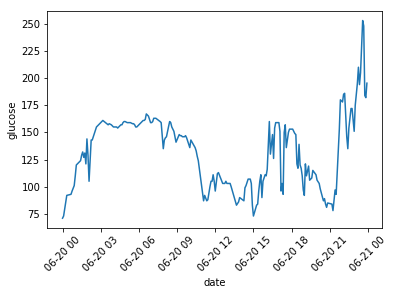

```python
# initial values of 1 day
day = data['2018-06-20']
sns.lineplot(x=day.index, y=day.glucose)
plt.xticks(rotation=45)
```

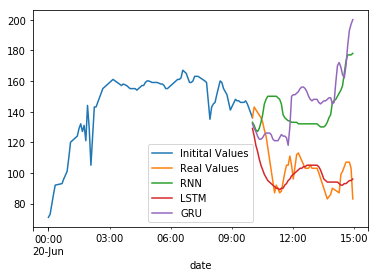

```python
plot_df.plot()
```